# Bank Churn Prediction - Problem Statement

### Background and Context

Businesses like banks that provide service have to worry about the problem of 'Churn' i.e. customers leaving and joining another service provider. It is important to understand which aspects of the service influence a customer's decision in this regard. Management can concentrate efforts on the improvement of service, keeping in mind these priorities.

### Objective

Given a Bank customer, build a neural network-based classifier that can determine whether they will leave or not in the next 6 months.

### Data Description

The case study is from an open-source dataset from Kaggle. The dataset contains 10,000 sample points with 14 distinct features such as CustomerId, CreditScore, Geography, Gender, Age, Tenure, Balance, etc.

### Data Dictionary

- CustomerId: Unique ID which is assigned to each customer
- Surname: Last name of the customer
- CreditScore: It defines the credit history of the customer.
- Geography: A customer’s location
- Gender: It defines the Gender of the customer
- Age: Age of the customer
- Tenure: Number of years for which the customer has been with the bank
- NumOfProducts: It refers to the number of products that a customer has purchased through the bank.
- Balance: Account balance
- HasCrCard: It is a categorical variable that decides whether the customer has a credit card or not.
- EstimatedSalary: Estimated salary
- isActiveMember: It is a categorical variable that decides whether the customer is an active member of the bank or not ( Active member in the sense, using bank products regularly, making transactions, etc )
- Exited: It is a categorical variable that decides whether the customer left the bank within six months or not. It can take two values

  ```
                0=No ( Customer did not leave the bank )
                1=Yes ( Customer left the bank )
  ```

```python
# Connect to the google drive
from google.colab import drive
drive.mount('/content/gdrive.py', force_remount=True)
```

```python
cd '/content'
```

```
/content
```

```python
cd 'gdrive.py/'
```

```
/content/gdrive.py
```

```python
cd 'MyDrive/'
```

```
/content/gdrive.py/MyDrive
```

```python
cd 'Colab Notebooks/Module 7/Project/'
```

```
/content/gdrive.py/MyDrive/Colab Notebooks/Module 7/Project
```

```python
#Reference class libraries
import pandas as pd
import numpy as np
from sklearn.model_selection import train_test_split
from sklearn.preprocessing import LabelEncoder, OneHotEncoder
from sklearn import model_selection
from sklearn.compose import ColumnTransformer
import matplotlib.pyplot as plt
import seaborn as sns
from sklearn.impute import SimpleImputer
import warnings
from sklearn.metrics import confusion_matrix
from sklearn.pipeline import Pipeline
from sklearn.model_selection import GridSearchCV
from sklearn.model_selection import RandomizedSearchCV
import tensorflow as tf
from tensorflow.keras.models import Sequential
from tensorflow.keras.layers import Dense
from tensorflow.keras.layers import Dense, Input, Dropout,BatchNormalization
from tensorflow.keras.wrappers.scikit_learn import KerasClassifier
import random
from tensorflow.keras import backend
random.seed(1)
np.random.seed(1)
tf.random.set_seed(1)
warnings.filterwarnings("ignore")
from tensorflow.keras import losses
from tensorflow.keras import optimizers
from keras import Sequential
from tensorflow.keras.layers import Dense
from tensorflow.keras.layers import BatchNormalization
from tensorflow.keras.layers import Dropout
from tensorflow.keras import Sequential
from tensorflow.keras.layers import Dense
```

### Load Data

```python
Data = pd.read_csv('Churn.csv')
```

```python
Data.shape
```

```
(10000, 14)
```

## **Data Overview**

```python
Data.head()
```

|  | RowNumber | CustomerId | Surname | CreditScore | Geography | Gender | Age | Tenure | Balance | NumOfProducts | HasCrCard | IsActiveMember | EstimatedSalary | Exited |
| --- | --- | --- | --- | --- | --- | --- | --- | --- | --- | --- | --- | --- | --- | --- |
| 0 | 1 | 15634602 | Hargrave | 619 | France | Female | 42 | 2 | 0.00 | 1 | 1 | 1 | 101348.88 | 1 |
| 1 | 2 | 15647311 | Hill | 608 | Spain | Female | 41 | 1 | 83807.86 | 1 | 0 | 1 | 112542.58 | 0 |
| 2 | 3 | 15619304 | Onio | 502 | France | Female | 42 | 8 | 159660.80 | 3 | 1 | 0 | 113931.57 | 1 |
| 3 | 4 | 15701354 | Boni | 699 | France | Female | 39 | 1 | 0.00 | 2 | 0 | 0 | 93826.63 | 0 |
| 4 | 5 | 15737888 | Mitchell | 850 | Spain | Female | 43 | 2 | 125510.82 | 1 | 1 | 1 | 79084.10 | 0 |

```python
Data.info()
```

```
<class 'pandas.core.frame.DataFrame'>
RangeIndex: 10000 entries, 0 to 9999
Data columns (total 14 columns):
 #   Column           Non-Null Count  Dtype
---  ------           --------------  -----
 0   RowNumber        10000 non-null  int64
 1   CustomerId       10000 non-null  int64
 2   Surname          10000 non-null  object
 3   CreditScore      10000 non-null  int64
 4   Geography        10000 non-null  object
 5   Gender           10000 non-null  object
 6   Age              10000 non-null  int64
 7   Tenure           10000 non-null  int64
 8   Balance          10000 non-null  float64
 9   NumOfProducts    10000 non-null  int64
 10  HasCrCard        10000 non-null  int64
 11  IsActiveMember   10000 non-null  int64
 12  EstimatedSalary  10000 non-null  float64
 13  Exited           10000 non-null  int64
dtypes: float64(2), int64(9), object(3)
memory usage: 1.1+ MB
```

#### Observations

- There are 10K rows and 14 columns.
- RowNumber and CustomerId appears to be a unique identifier and may be something to drop.
- Surname has no measurable value and can be dropped.
- Geography and Gender will need to be converted to one hot encoding.
- HasCard, IsActiveMember, and Exited can be converted to Categorical data type.

```python
# Check for Dupes
Data.duplicated().sum()
```

```
0
```

```python
# Check for missing values in the data
round(Data.isnull().sum() / Data.isnull().count() * 100, 2)
```

```
RowNumber          0.0
CustomerId         0.0
Surname            0.0
CreditScore        0.0
Geography          0.0
Gender             0.0
Age                0.0
Tenure             0.0
Balance            0.0
NumOfProducts      0.0
HasCrCard          0.0
IsActiveMember     0.0
EstimatedSalary    0.0
Exited             0.0
dtype: float64
```

```python
#Check if any of the data is for members over time.  If we have any members with a count of more than 1 we may have customers over time.
Data['CustomerId'].value_counts()
```

```
15634602    1
15667932    1
15766185    1
15667632    1
15599024    1
           ..
15599078    1
15702300    1
15660735    1
15671390    1
15628319    1
Name: CustomerId, Length: 10000, dtype: int64
```

```python
#As a secondary check for possible customers over time, checking to see if we have any duplicate Customer Ids which would indicate records over time.
df_dupes = pd.DataFrame(Data, columns=['CustomerId'])
df_dupes.duplicated().sum()
```

```
0
```

```python
#Checking to see if we have multiple records for the same customer by checking surnames.
df_dupes = pd.DataFrame(Data, columns=['Surname'])
df_dupes.duplicated().sum()
```

```
7068
```

#### Observations

- We dont have any duplicates of CustomerIds so each record uniquely identifies a single customer.
- We do have 7068 duplicate names. This could potentially be members of a single household.

```python
df_dupes.value_counts()
```

```
Surname
Smith         32
Martin        29
Scott         29
Walker        28
Brown         26
              ..
Etheridge      1
Milliner       1
Milligan       1
Eva            1
Kuykendall     1
Length: 2932, dtype: int64
```

#### Observations

- Upon closer look the names that appear more than once are very common names. This feature cannot accurately be used to identify household.

```python
#drop unneeded columns
df = Data.copy()

# ID column consists of uniques ID for clients and hence will not add value to the modeling
df.drop(columns="RowNumber", inplace=True)
df.drop(columns="CustomerId", inplace=True)
df.drop(columns="Surname", inplace=True)
```

## **EDA**

### **Univariate Analysis**

```python
Data["Geography"].value_counts()
```

```
France     5014
Germany    2509
Spain      2477
Name: Geography, dtype: int64
```

```python
Data["Gender"].value_counts()
```

```
Male      5457
Female    4543
Name: Gender, dtype: int64
```

#### Observations

```python
# Check the distribution of values in the flag fields
Data["HasCrCard"].value_counts()
```

```
1    7055
0    2945
Name: HasCrCard, dtype: int64
```

```python
Data["IsActiveMember"].value_counts()
```

```
1    5151
0    4849
Name: IsActiveMember, dtype: int64
```

```python
Data["Exited"].value_counts()
```

```
0    7963
1    2037
Name: Exited, dtype: int64
```

#### Observations

- Approximately 2/3rds of Customers have a credit card
- Slightly over half of the members in the data are considered to be actively using bank services. It would be interesting to see if there is a correlation between "inactive" and "exited" members.
- We have a roughly 80/20 split of members who are currently bank customers vs exited. It may be worthwhile to try oversampling to balance the "Exited" data between the 0 and 1 class.

```python
# Function to plot a boxplot and a histogram along the same scale.


def histogram_boxplot(data, feature, figsize=(12, 7), kde=False, bins=None):
    """
    Boxplot and histogram combined

    data: dataframe
    feature: dataframe column
    figsize: size of figure (default (12,7))
    kde: whether to the show density curve (default False)
    bins: number of bins for histogram (default None)
    """
    f2, (ax_box2, ax_hist2) = plt.subplots(
        nrows=2,  # Number of rows of the subplot grid= 2
        sharex=True,  # x-axis will be shared among all subplots
        gridspec_kw={"height_ratios": (0.25, 0.75)},
        figsize=figsize,
    )  # creating the 2 subplots
    sns.boxplot(
        data=data, x=feature, ax=ax_box2, showmeans=True, color="violet"
    )  # boxplot will be created and a star will indicate the mean value of the column
    sns.histplot(
        data=data, x=feature, kde=kde, ax=ax_hist2, bins=bins, palette="winter"
    ) if bins else sns.histplot(
        data=data, x=feature, kde=kde, ax=ax_hist2
    )  # For histogram
    ax_hist2.axvline(
        data[feature].mean(), color="green", linestyle="--"
    )  # Add mean to the histogram
    ax_hist2.axvline(
        data[feature].median(), color="black", linestyle="-"
    )  # Add median to the histogram
```

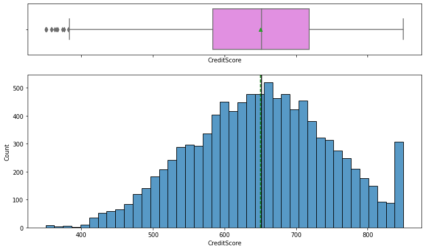

```python
histogram_boxplot(df, "CreditScore")
```

There are some outliers on the lower end of CreditScore. They are not strong enough to create a big gulf between Mean and Median but they may be worth adjusting. I will replace anything lower than the 2nd percentile with the 2nd percentile.

```python
#Replace anything lower than the 2nd percentile with the 2nd percentile
CreditScore_98quantile = np.quantile(df['CreditScore'], .02)
df['CreditScore'] = df['CreditScore'].apply(lambda x: x if x >=  np.quantile(df['CreditScore'], .02) else CreditScore_98quantile)
```

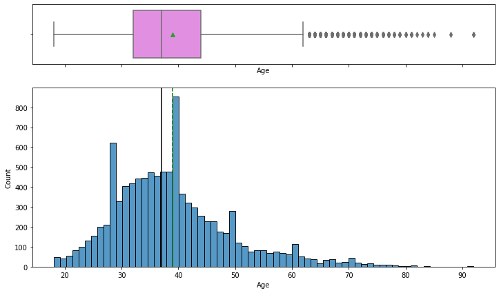

```python
histogram_boxplot(df, "Age")
```

- Age has some outliers on the far end of age. I will set anything greater than the 98th percentile equal to the 98th percentile.

```python
#Replace anything greater than the 98th percentile with the 98th percentile for Age
Age_98quantile = np.quantile(df['Age'], .98)
df['Age'] = df['Age'].apply(lambda x: x if x <=  np.quantile(df['Age'], .98) else Age_98quantile)
```

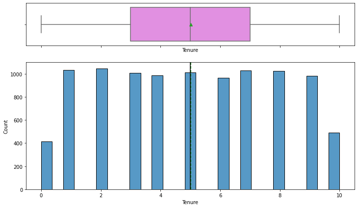

```python
histogram_boxplot(Data, "Tenure")
```

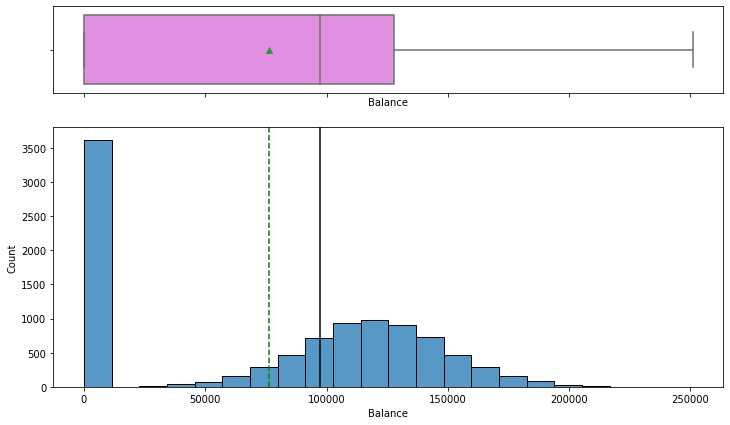

```python
histogram_boxplot(Data, "Balance")
```

```python
(Data["Balance"] == 0).sum()
```

```
3617
```

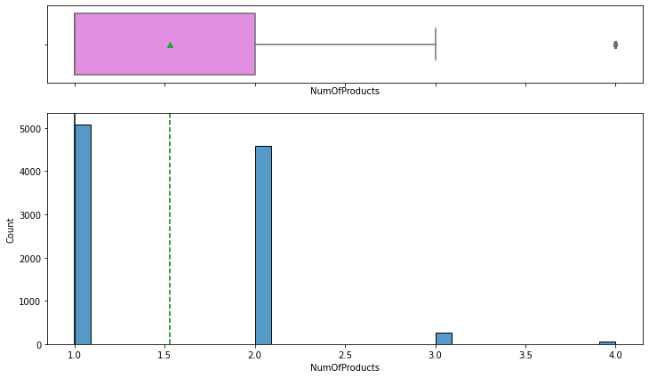

```python
histogram_boxplot(Data, "NumOfProducts")
```

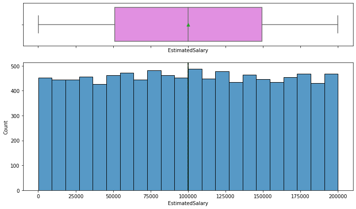

```python
histogram_boxplot(Data, "EstimatedSalary")
```

```python
df.describe()
```

|  | CreditScore | Age | Tenure | Balance | NumOfProducts | HasCrCard | IsActiveMember | EstimatedSalary | Exited |
| --- | --- | --- | --- | --- | --- | --- | --- | --- | --- |
| count | 10000.000000 | 10000.000000 | 10000.000000 | 10000.000000 | 10000.000000 | 10000.00000 | 10000.000000 | 10000.000000 | 10000.000000 |
| mean | 651.038500 | 38.806100 | 5.012800 | 76485.889288 | 1.530200 | 0.70550 | 0.515100 | 100090.239881 | 0.203700 |
| std | 95.474703 | 10.120462 | 2.892174 | 62397.405202 | 0.581654 | 0.45584 | 0.499797 | 57510.492818 | 0.402769 |
| min | 452.000000 | 18.000000 | 0.000000 | 0.000000 | 1.000000 | 0.00000 | 0.000000 | 11.580000 | 0.000000 |
| 25% | 584.000000 | 32.000000 | 3.000000 | 0.000000 | 1.000000 | 0.00000 | 0.000000 | 51002.110000 | 0.000000 |
| 50% | 652.000000 | 37.000000 | 5.000000 | 97198.540000 | 1.000000 | 1.00000 | 1.000000 | 100193.915000 | 0.000000 |
| 75% | 718.000000 | 44.000000 | 7.000000 | 127644.240000 | 2.000000 | 1.00000 | 1.000000 | 149388.247500 | 0.000000 |
| max | 850.000000 | 67.000000 | 10.000000 | 250898.090000 | 4.000000 | 1.00000 | 1.000000 | 199992.480000 | 1.000000 |

### **Bivariate Analysis**

```python
### Function to plot distributions


def distribution_plot_wrt_target(data, predictor, target):

    fig, axs = plt.subplots(2, 2, figsize=(12, 10))

    target_uniq = data[target].unique()

    axs[0, 0].set_title("Distribution of target for target=" + str(target_uniq[0]))
    sns.histplot(
        data=data[data[target] == target_uniq[0]],
        x=predictor,
        kde=True,
        ax=axs[0, 0],
        color="teal",
    )

    axs[0, 1].set_title("Distribution of target for target=" + str(target_uniq[1]))
    sns.histplot(
        data=data[data[target] == target_uniq[1]],
        x=predictor,
        kde=True,
        ax=axs[0, 1],
        color="orange",
    )

    axs[1, 0].set_title("Boxplot w.r.t target")
    sns.boxplot(data=data, x=target, y=predictor, ax=axs[1, 0], palette="gist_rainbow")

    axs[1, 1].set_title("Boxplot (without outliers) w.r.t target")
    sns.boxplot(
        data=data,
        x=target,
        y=predictor,
        ax=axs[1, 1],
        showfliers=False,
        palette="gist_rainbow",
    )

    plt.tight_layout()
    plt.show()
```

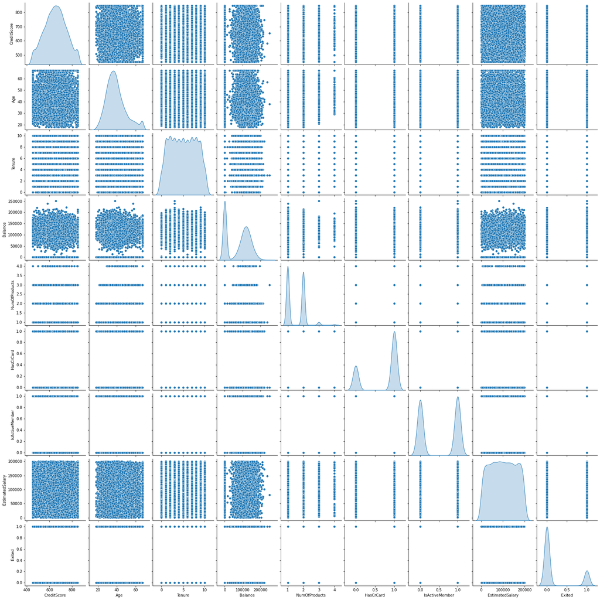

```python
sns.pairplot(df, diag_kind='kde')   # to plot density curve instead of histogram on the diag
```

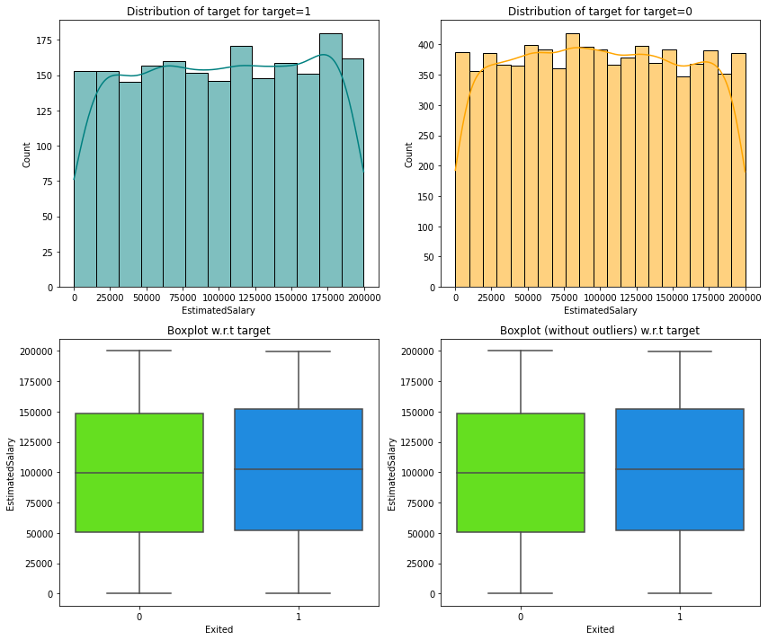

```python
#Compare Estimated Salary and the Target variable
distribution_plot_wrt_target(df, "EstimatedSalary", "Exited")
```

#### Observation

- The distribution of Estimated Salary in relation to the Exited Target Variable between. This column doesnt appear to be adding any useful information and may be something we can drop.

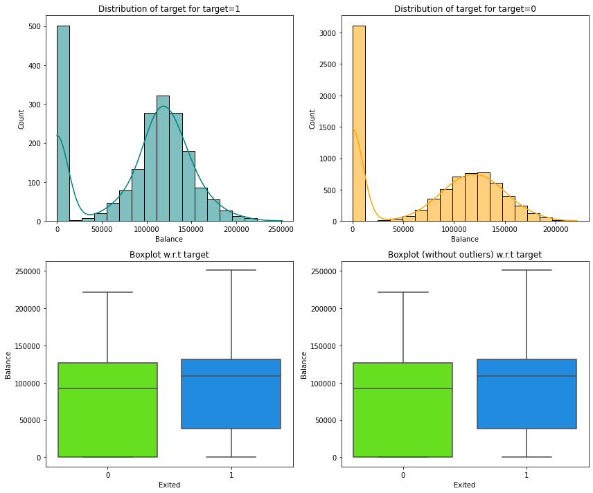

```python
#Compare Estimated Salary and the Target variable
distribution_plot_wrt_target(df, "Balance", "Exited")
```

```python
# function to plot stacked bar chart


def stacked_barplot(data, predictor, target):
    """
    Print the category counts and plot a stacked bar chart

    data: dataframe
    predictor: independent variable
    target: target variable
    """
    count = data[predictor].nunique()
    sorter = data[target].value_counts().index[-1]
    tab1 = pd.crosstab(data[predictor], data[target], margins=True).sort_values(
        by=sorter, ascending=False
    )
    print(tab1)
    print("-" * 120)
    tab = pd.crosstab(data[predictor], data[target], normalize="index").sort_values(
        by=sorter, ascending=False
    )
    tab.plot(kind="bar", stacked=True, figsize=(count + 1, 5))
    plt.legend(
        loc="lower left",
        frameon=False,
    )
    plt.legend(loc="upper left", bbox_to_anchor=(1, 1))
    plt.show()
```

```
Exited             0     1    All
IsActiveMember
All             7963  2037  10000
0               3547  1302   4849
1               4416   735   5151
------------------------------------------------------------------------------------------------------------------------
```

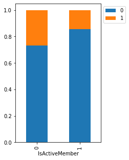

```python
stacked_barplot(Data, "IsActiveMember", "Exited")
```

```
Exited        0     1    All
HasCrCard
All        7963  2037  10000
1          5631  1424   7055
0          2332   613   2945
------------------------------------------------------------------------------------------------------------------------
```

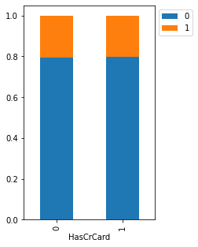

```python
stacked_barplot(Data, "HasCrCard", "Exited")
```

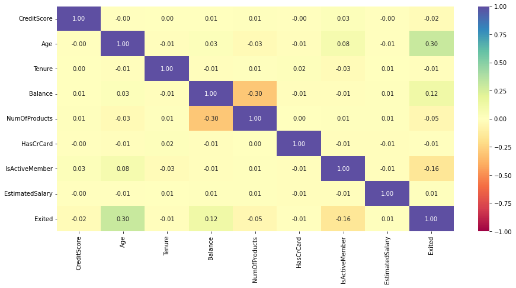

```python
## Lets take a look at a heat map for bivariate analysis
plt.figure(figsize=(15, 7))
sns.heatmap(df.corr(), annot=True, vmin=-1, vmax=1, fmt=".2f", cmap="Spectral")
plt.show()
```

#### Observations

- There dont seem to be any strong correlations between features.
- As one may expect, there is significantly more attrition among members not considered as Active.
- Having a credit card appears to have no impact on Attrition.

```
Exited            0     1    All
NumOfProducts
All            7963  2037  10000
1              3675  1409   5084
2              4242   348   4590
3                46   220    266
4                 0    60     60
------------------------------------------------------------------------------------------------------------------------
```

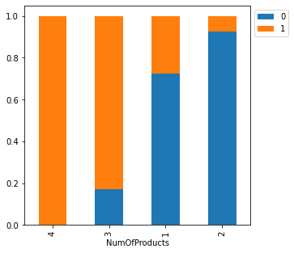

```python
stacked_barplot(Data, "NumOfProducts", "Exited")
```

- This is very surprising. All members with 4 products and about 80% of members with 3 products have attrited. It appears that 2 products is really the sweet spot.

```
Exited     0     1    All
Tenure
All     7963  2037  10000
1        803   232   1035
3        796   213   1009
9        771   213    984
5        803   209   1012
4        786   203    989
2        847   201   1048
8        828   197   1025
6        771   196    967
7        851   177   1028
10       389   101    490
0        318    95    413
------------------------------------------------------------------------------------------------------------------------
```

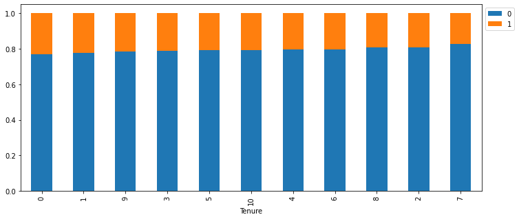

```python
stacked_barplot(Data, "Tenure", "Exited")
```

- There isnt an enormous difference in attrition from shortest to longest tenured members.
- It is not surprising that members who have been with the Bank for 0 or 1 year should have a high attrition rate.
- Interestingly members with 9 or 10 years of tenure are more likely to attrit than someone with a 2 year tenure.

```
Exited      0    1   All
Balance
0.0      3117  500  3617
All      3117  500  3617
------------------------------------------------------------------------------------------------------------------------
```

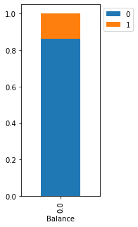

```python
#Check what just the 0 Balance looks like in relation to attrition
df_bal_zero = df.loc[(df['Balance']==0)]
stacked_barplot(df_bal_zero, "Balance", "Exited")
```

- Interestingly people with a zero balance are less likely to attrit than the average which is roughly 20%.

```python
# Drop Estimate Salary
df.drop(columns="EstimatedSalary", inplace=True)
```

```python
# I found that if I dropped the 0 value balance, I got more accurate results
# dropping the 0 value to get a more normal curve
df = df[df.Balance != 0]
```

### **Split Data**

```python
## Separating Independent and Dependent Columns
X = df.drop(['Exited'],axis=1)
Y = df[['Exited']]
```

```python
# Splitting the dataset into the Training and Testing set.

X_train, X_test, y_train, y_test = train_test_split(X,Y, test_size = 0.2, random_state = 1,stratify = Y)
```

### **Encoding Categorical Columns**

```python
from sklearn.preprocessing import LabelEncoder
labelencoder_RE = LabelEncoder()
X_train['Gender']= labelencoder_RE.fit_transform(X_train['Gender'])
X_test['Gender']= labelencoder_RE.transform(X_test['Gender'])
```

```python
from sklearn.preprocessing import LabelEncoder
labelencoder_RE = LabelEncoder()
X_train['Geography']= labelencoder_RE.fit_transform(X_train['Geography'])
X_test['Geography']= labelencoder_RE.transform(X_test['Geography'])
```

```python
X_train.head()
```

|  | CreditScore | Geography | Gender | Age | Tenure | Balance | NumOfProducts | HasCrCard | IsActiveMember |
| --- | --- | --- | --- | --- | --- | --- | --- | --- | --- |
| 498 | 757.0 | 1 | 1 | 26.0 | 8 | 121581.56 | 2 | 1 | 1 |
| 6433 | 452.0 | 2 | 1 | 53.0 | 5 | 167259.44 | 1 | 1 | 1 |
| 8851 | 782.0 | 1 | 1 | 42.0 | 7 | 126428.38 | 1 | 1 | 0 |
| 4288 | 577.0 | 1 | 0 | 31.0 | 4 | 61211.18 | 1 | 1 | 1 |
| 9734 | 667.0 | 1 | 1 | 67.0 | 3 | 77356.92 | 2 | 1 | 1 |

```python
###Checking the shape of train and test sets
print(X_train.shape)
print(X_test.shape)
print(y_train.shape)
print(y_test.shape)
```

```
(5106, 9)
(1277, 9)
(5106, 1)
(1277, 1)
```

### **Scale Data**

```python
# Scale the data to reduce bias
# to scale the data using z-score
from sklearn.preprocessing import StandardScaler
sc = StandardScaler()
X_train = pd.DataFrame(sc.fit_transform(X_train))
X_test = pd.DataFrame(sc.fit_transform(X_test))
```

```python
X_train
```

|  | 0 | 1 | 2 | 3 | 4 | 5 | 6 | 7 | 8 |
| --- | --- | --- | --- | --- | --- | --- | --- | --- | --- |
| 0 | 1.099747 | 0.278923 | 0.910742 | -1.291638 | 1.039371 | 0.051860 | 1.089473 | 0.653799 | 0.980988 |
| 1 | -2.093803 | 1.613673 | 0.910742 | 1.368632 | 0.012602 | 1.568192 | -0.663710 | 0.653799 | 0.980988 |
| 2 | 1.361513 | 0.278923 | 0.910742 | 0.284818 | 0.697114 | 0.212756 | -0.663710 | 0.653799 | -1.019381 |
| 3 | -0.784971 | 0.278923 | -1.098005 | -0.798996 | -0.329655 | -1.952207 | -0.663710 | 0.653799 | 0.980988 |
| 4 | 0.157388 | 0.278923 | 0.910742 | 2.748031 | -0.671911 | -1.416230 | 1.089473 | 0.653799 | 0.980988 |
| ... | ... | ... | ... | ... | ... | ... | ... | ... | ... |
| 5101 | -0.575558 | 1.613673 | 0.910742 | 0.383347 | -1.014167 | -1.157122 | -0.663710 | -1.529522 | 0.980988 |
| 5102 | -0.669794 | -1.055828 | 0.910742 | -0.109296 | -1.356424 | 0.141148 | -0.663710 | 0.653799 | -1.019381 |
| 5103 | -0.491793 | -1.055828 | 0.910742 | 1.270103 | -1.356424 | -1.881214 | -0.663710 | 0.653799 | -1.019381 |
| 5104 | 0.314448 | -1.055828 | 0.910742 | -1.094581 | 1.723884 | 2.679120 | -0.663710 | -1.529522 | 0.980988 |
| 5105 | -0.156732 | -1.055828 | -1.098005 | 0.875989 | 0.697114 | 0.358110 | 1.089473 | 0.653799 | 0.980988 |

5106 rows × 9 columns

```python
y_train
```

|  | Exited |
| --- | --- |
| 498 | 0 |
| 6433 | 0 |
| 8851 | 0 |
| 4288 | 0 |
| 9734 | 0 |
| ... | ... |
| 8535 | 1 |
| 4683 | 0 |
| 400 | 0 |
| 7492 | 1 |
| 3167 | 1 |

5106 rows × 1 columns

## **Model Building**

The score of most interest for this problem should be Recall because failing to correctly identify a member who is exiting is more costly to the bank than misidentifying a member as exiting who is not existing. However, since the bank is also interested in identifying what helps them retain members, there is also a case to be made for tracking F1 Score. I will track both Recall and F1 Score.

### **Model 1**

To start, I'm going to build a very basic model with two layers to get a baseline.

```python
backend.clear_session()
#Fixing the seed for random number generators so that we can ensure we receive the same output everytime
np.random.seed(1)
import random
random.seed(1)
tf.random.set_seed(1)
```

```python
# Initializing the ANN
model_1 = Sequential()
#Adding two layers
model_1.add(Dense(activation = 'relu', input_dim = 9, units=64))
model_1.add(Dense(32, activation='relu'))
#Output layer with probability output
model_1.add(Dense(1, activation = 'sigmoid'))
```

```python
# Create optimizer with default learning rate
# Compile the model
# Cross entropy is used for categorical results
model_1.compile(optimizer='Adam', loss='binary_crossentropy', metrics=['accuracy'])
```

```python
model_1.summary()
```

```
Model: "sequential"
_________________________________________________________________
 Layer (type)                Output Shape              Param #
=================================================================
 dense (Dense)               (None, 64)                640

 dense_1 (Dense)             (None, 32)                2080

 dense_2 (Dense)             (None, 1)                 33

=================================================================
Total params: 2,753
Trainable params: 2,753
Non-trainable params: 0
_________________________________________________________________
```

```python
history=model_1.fit(X_train, y_train,
          validation_split=0.2,
          epochs=50,
          batch_size=32,verbose=1)
```

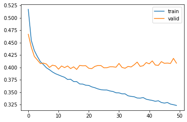

```python
# Capturing learning history per epoch
hist  = pd.DataFrame(history.history)
hist['epoch'] = history.epoch

# Plotting accuracy at different epochs
plt.plot(hist['loss'])
plt.plot(hist['val_loss'])
plt.legend(("train" , "valid") , loc =0)

#Printing results
results = model_1.evaluate(X_test, y_test)
```

```python
# Since this is a statistical result, we will flag any prediction that is greater than .5 as True, else False.
y_pred=model_1.predict(X_test)
y_pred = (y_pred > 0.5)
y_pred
```

```
array([[False],
       [False],
       [False],
       ...,
       [False],
       [ True],
       [ True]])
```

```python
df_pred = pd.DataFrame(y_pred, columns = ['Column_A'])
```

```python
#Distribution of Exited Predictions - True to False predictions
df_pred["Column_A"].value_counts()
```

```
False    1059
True      218
Name: Column_A, dtype: int64
```

```python
def make_confusion_matrix(cf,
                          group_names=None,
                          categories='auto',
                          count=True,
                          percent=True,
                          cbar=True,
                          xyticks=True,
                          xyplotlabels=True,
                          sum_stats=True,
                          figsize=None,
                          cmap='Blues',
                          title=None):
    '''
    This function will make a pretty plot of an sklearn Confusion Matrix cm using a Seaborn heatmap visualization.
    Arguments
    '''


    # CODE TO GENERATE TEXT INSIDE EACH SQUARE
    blanks = ['' for i in range(cf.size)]

    if group_names and len(group_names)==cf.size:
        group_labels = ["{}\n".format(value) for value in group_names]
    else:
        group_labels = blanks

    if count:
        group_counts = ["{0:0.0f}\n".format(value) for value in cf.flatten()]
    else:
        group_counts = blanks

    if percent:
        group_percentages = ["{0:.2%}".format(value) for value in cf.flatten()/np.sum(cf)]
    else:
        group_percentages = blanks

    box_labels = [f"{v1}{v2}{v3}".strip() for v1, v2, v3 in zip(group_labels,group_counts,group_percentages)]
    box_labels = np.asarray(box_labels).reshape(cf.shape[0],cf.shape[1])


    # CODE TO GENERATE SUMMARY STATISTICS & TEXT FOR SUMMARY STATS
    if sum_stats:
        #Accuracy is sum of diagonal divided by total observations
        accuracy  = np.trace(cf) / float(np.sum(cf))



    # SET FIGURE PARAMETERS ACCORDING TO OTHER ARGUMENTS
    if figsize==None:
        #Get default figure size if not set
        figsize = plt.rcParams.get('figure.figsize')

    if xyticks==False:
        #Do not show categories if xyticks is False
        categories=False


    # MAKE THE HEATMAP VISUALIZATION
    plt.figure(figsize=figsize)
    sns.heatmap(cf,annot=box_labels,fmt="",cmap=cmap,cbar=cbar,xticklabels=categories,yticklabels=categories)


    if title:
        plt.title(title)
```

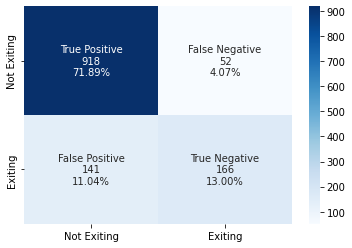

```python
#Calculating the confusion matrix
from sklearn.metrics import confusion_matrix
cm=confusion_matrix(y_test, y_pred)
labels = ['True Positive','False Negative','False Positive','True Negative']
categories = [ 'Not Exiting','Exiting']
make_confusion_matrix(cm,
                      group_names=labels,
                      categories=categories,
                      cmap='Blues')
```

```python
#Accuracy as per the classification report
from sklearn import metrics
cr=metrics.classification_report(y_test,y_pred)
print(cr)
```

```
              precision    recall  f1-score   support

           0       0.87      0.95      0.90       970
           1       0.76      0.54      0.63       307

    accuracy                           0.85      1277
   macro avg       0.81      0.74      0.77      1277
weighted avg       0.84      0.85      0.84      1277
```

```python
#Check roc_auc for imbalanced dataset
from sklearn.metrics import roc_auc_score
roc_auc_score(y_test,y_pred, average=None)
#clf = LogisticRegression(solver="liblinear", random_state=0).fit(X, y)

#roc_auc_score(y_test, clf.decision_function(y_pred))
```

```
0.7435541824775849
```

#### Observations

- The predictions on Exited = True members is far far lower than Exited = False. This base model returns only a slightly better than a 50% chance of an accurate prediction on Recall and a 63% accuracy on F1-Score.
- The model is not terribly noisy and does not appear to be terribly overfitting although accuracy has room for improvement.

```
Best Threshold=0.249005, G-Mean=0.781
```

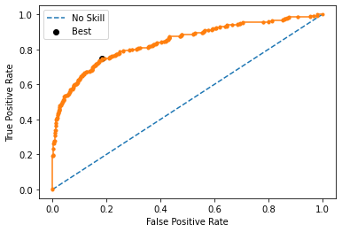

```python
from sklearn.metrics import roc_curve

from matplotlib import pyplot


# predict probabilities
yhat1 = model_1.predict(X_test)
# keep probabilities for the positive outcome only
yhat1 = yhat1[:, 0]
# calculate roc curves
fpr, tpr, thresholds1 = roc_curve(y_test, yhat1)
# calculate the g-mean for each threshold
gmeans1 = np.sqrt(tpr * (1-fpr))
# locate the index of the largest g-mean
ix = np.argmax(gmeans1)
print('Best Threshold=%f, G-Mean=%.3f' % (thresholds1[ix], gmeans1[ix]))
# plot the roc curve for the model
pyplot.plot([0,1], [0,1], linestyle='--', label='No Skill')
pyplot.plot(fpr, tpr, marker='.')
pyplot.scatter(fpr[ix], tpr[ix], marker='o', color='black', label='Best')
# axis labels
pyplot.xlabel('False Positive Rate')
pyplot.ylabel('True Positive Rate')
pyplot.legend()
# show the plot
pyplot.show()
```

```python
#Predicting the results using best as a threshold
y_pred_e1=model_1.predict(X_test)
y_pred_e1 = (y_pred_e1 > thresholds1[ix])
y_pred_e1
```

```
array([[False],
       [False],
       [False],
       ...,
       [False],
       [ True],
       [ True]])
```

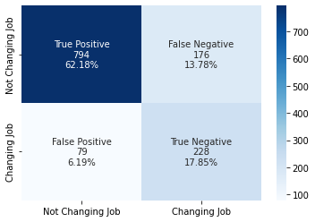

```python
#Calculating the confusion matrix
from sklearn.metrics import confusion_matrix
cm1=confusion_matrix(y_test, y_pred_e1)
labels = ['True Positive','False Negative','False Positive','True Negative']
categories = [ 'Not Changing Job','Changing Job']
make_confusion_matrix(cm1,
                      group_names=labels,
                      categories=categories,
                      cmap='Blues')
```

```python
#Accuracy as per the classification report
from sklearn import metrics
cr=metrics.classification_report(y_test,y_pred_e1)
print(cr)
```

```
              precision    recall  f1-score   support

           0       0.91      0.82      0.86       970
           1       0.56      0.74      0.64       307

    accuracy                           0.80      1277
   macro avg       0.74      0.78      0.75      1277
weighted avg       0.83      0.80      0.81      1277
```

#### Observations

- The ROC-AUC is relatively high and appears good at distinguishing 0 from 1 in this case of an imbalanced data. We may not ultimately need to balance the data.

### **Model 2**

### **SMOTE**

Trying the same model with oversampled data

```python
##Applying SMOTE on train and test
from imblearn.over_sampling import SMOTE
smote=SMOTE(sampling_strategy='not majority')
X_sm , y_sm = smote.fit_resample(X_train,y_train)
```

```python
backend.clear_session()
np.random.seed(1)
import random
random.seed(1)
tf.random.set_seed(1)
```

```python
# Initializing the ANN
model_smote = Sequential()
#Add 2 layers
model_smote.add(Dense(activation = 'relu', input_dim = 9, units=64))
model_smote.add(Dense(32, activation='relu'))
# Adding the output layer
model_smote.add(Dense(1, activation = 'sigmoid'))
```

```python
# Create optimizer with default learning rate
# Compile the model
model_smote.compile(optimizer='Adam', loss='binary_crossentropy', metrics=['accuracy'])
```

```python
model_smote.summary()
```

```
Model: "sequential"
_________________________________________________________________
 Layer (type)                Output Shape              Param #
=================================================================
 dense (Dense)               (None, 64)                640

 dense_1 (Dense)             (None, 32)                2080

 dense_2 (Dense)             (None, 1)                 33

=================================================================
Total params: 2,753
Trainable params: 2,753
Non-trainable params: 0
_________________________________________________________________
```

```python
history_smote=model_smote.fit(X_sm, y_sm,
          validation_split=0.2,
          epochs=50,
          batch_size=32,verbose=1)
```

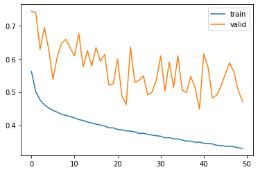

```python
# Capturing learning history per epoch
hist_smote  = pd.DataFrame(history_smote.history)
hist_smote['epoch'] = history_smote.epoch

# Plotting accuracy at different epochs
plt.plot(hist_smote['loss'])
plt.plot(hist_smote['val_loss'])
plt.legend(("train" , "valid") , loc =0)

#Printing results
results_smote = model_smote.evaluate(X_sm, y_sm)
```

```python
y_pred_smote=model_smote.predict(X_test)
y_pred_smote = (y_pred_smote > 0.5)
y_pred_smote.shape
```

```
(1277, 1)
```

```python
#Accuracy as per the classification report
from sklearn import metrics
cr=metrics.classification_report(y_test,y_pred_smote)
print(cr)
```

```
              precision    recall  f1-score   support

           0       0.88      0.87      0.88       970
           1       0.61      0.63      0.62       307

    accuracy                           0.82      1277
   macro avg       0.75      0.75      0.75      1277
weighted avg       0.82      0.82      0.82      1277
```

#### Observation

- Oversampling improves recall but slightly reduces F1 Score.

```
Best Threshold=0.360314, G-Mean=0.750
```

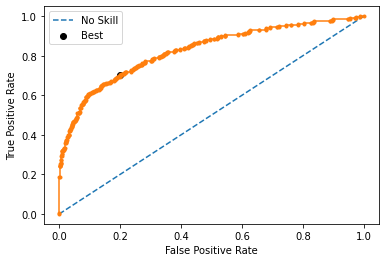

```python
# predict probabilities
yhat2 = model_smote.predict(X_test)
# keep probabilities for the positive outcome only
yhat2 = yhat2[:, 0]
# calculate roc curves
fpr, tpr, thresholds2 = roc_curve(y_test, yhat2)
# calculate the g-mean for each threshold
gmeans2 = np.sqrt(tpr * (1-fpr))
# locate the index of the largest g-mean
ix = np.argmax(gmeans2)
print('Best Threshold=%f, G-Mean=%.3f' % (thresholds2[ix], gmeans2[ix]))
# plot the roc curve for the model
pyplot.plot([0,1], [0,1], linestyle='--', label='No Skill')
pyplot.plot(fpr, tpr, marker='.')
pyplot.scatter(fpr[ix], tpr[ix], marker='o', color='black', label='Best')
# axis labels
pyplot.xlabel('False Positive Rate')
pyplot.ylabel('True Positive Rate')
pyplot.legend()
# show the plot
pyplot.show()
```

```python
#Predicting the results using best as a threshold
y_pred_smote_e2=model_smote.predict(X_test)
y_pred_smote_e2 = (y_pred_e1 > thresholds1[ix])
y_pred_smote_e2
```

```
array([[False],
       [False],
       [False],
       ...,
       [False],
       [ True],
       [ True]])
```

[figure not shown]

```python
#Calculating the confusion matrix
cm2=confusion_matrix(y_test, y_pred_smote_e2)
labels = ['True Positive','False Negative','False Positive','True Negative']
categories = [ 'Not Changing Job','Changing Job']
make_confusion_matrix(cm1,
                      group_names=labels,
                      categories=categories,
                      cmap='Blues')
```

```python
#Accuracy as per the classification report
cr=metrics.classification_report(y_test,y_pred_smote_e2)
print(cr)
```

```
              precision    recall  f1-score   support

           0       0.91      0.82      0.86       970
           1       0.56      0.74      0.64       307

    accuracy                           0.80      1277
   macro avg       0.74      0.78      0.75      1277
weighted avg       0.83      0.80      0.81      1277
```

#### Observation

- The model is overfitting and is quite noisy.
- The accuracy of recall for Exited = 1 has improved from .54 to .63.
- F1 Score for Exited = 1 has slightly gone down from .63 to .62

### **Model 3**

For this model I will add layers and continue to keep to use the balanced data. I will also add Dropout and add 2 a layer.

```python
backend.clear_session()
np.random.seed(1)
import random
random.seed(1)
tf.random.set_seed(1)
```

```python
model3 = Sequential()
model3.add(Dense(256,activation='relu',input_dim = X_train.shape[1]))
#model3.add(BatchNormalization())
model3.add(Dropout(0.2))
model3.add(Dense(124,activation='relu',kernel_initializer='he_uniform'))
#model3.add(BatchNormalization())
model3.add(Dropout(0.2))
model3.add(Dense(64,activation='relu',kernel_initializer='he_uniform'))
#model3.add(BatchNormalization())
model3.add(Dropout(0.2))
model3.add(Dense(32,activation='relu',kernel_initializer='he_uniform'))
model3.add(Dense(1, activation = 'sigmoid'))
```

```python
# Create optimizer with default learning rate
# Compile the model
model3.compile(optimizer='Adam', loss='binary_crossentropy', metrics=['accuracy'])
```

```python
history_3 = model3.fit(X_sm,y_sm,batch_size=64,epochs=50,verbose=1,validation_split = 0.2)
```

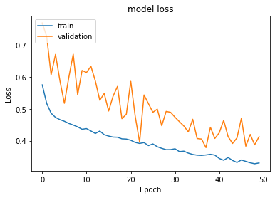

```python
#Plotting Train Loss vs Validation Loss
plt.plot(history_3.history['loss'])
plt.plot(history_3.history['val_loss'])
plt.title('model loss')
plt.ylabel('Loss')
plt.xlabel('Epoch')
plt.legend(['train', 'validation'], loc='upper left')
plt.show()
```

#### Observation

- The model is less noisy than in model 2 but still noisy and overfit due to the gap between Validation and Test results.

```
Best Threshold=0.381975, G-Mean=0.763
```

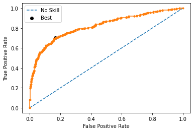

```python
# predict probabilities
yhat3 = model3.predict(X_test)
# keep probabilities for the positive outcome only
yhat3 = yhat3[:, 0]
# calculate roc curves
fpr, tpr, thresholds3 = roc_curve(y_test, yhat3)
# calculate the g-mean for each threshold
gmeans3 = np.sqrt(tpr * (1-fpr))
# locate the index of the largest g-mean
ix = np.argmax(gmeans3)
print('Best Threshold=%f, G-Mean=%.3f' % (thresholds3[ix], gmeans3[ix]))
# plot the roc curve for the model
pyplot.plot([0,1], [0,1], linestyle='--', label='No Skill')
pyplot.plot(fpr, tpr, marker='.')
pyplot.scatter(fpr[ix], tpr[ix], marker='o', color='black', label='Best')
# axis labels
pyplot.xlabel('False Positive Rate')
pyplot.ylabel('True Positive Rate')
pyplot.legend()
# show the plot
pyplot.show()
```

```python
y_pred_e3=model3.predict(X_test)
y_pred_e3 = (y_pred_e3 > thresholds3[ix])
```

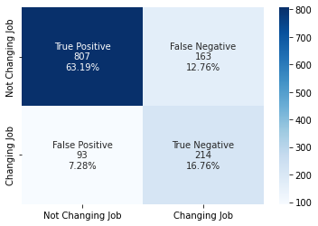

```python
#Calculating the confusion matrix
cm3=confusion_matrix(y_test, y_pred_e3)
labels = ['True Positive','False Negative','False Positive','True Negative']
categories = [ 'Not Changing Job','Changing Job']
make_confusion_matrix(cm3,
                      group_names=labels,
                      categories=categories,
                      cmap='Blues')
```

```python
#Accuracy as per the classification report
cr3=metrics.classification_report(y_test,y_pred_e3)
print(cr3)
```

```
              precision    recall  f1-score   support

           0       0.90      0.83      0.86       970
           1       0.57      0.70      0.63       307

    accuracy                           0.80      1277
   macro avg       0.73      0.76      0.74      1277
weighted avg       0.82      0.80      0.81      1277
```

### **Model 4**

Here I will drop Dropout as it had not been helpful and will add Normalization.

```python
backend.clear_session()
np.random.seed(1)
import random
random.seed(1)
tf.random.set_seed(1)
```

```python
model4 = Sequential()
model4.add(Dense(256,activation='relu',input_dim = X_train.shape[1]))
model4.add(BatchNormalization())
#model3.add(Dropout(0.2))
model4.add(Dense(124,activation='relu',kernel_initializer='he_uniform'))
model4.add(BatchNormalization())
#model3.add(Dropout(0.2))
model4.add(Dense(64,activation='relu',kernel_initializer='he_uniform'))
model4.add(BatchNormalization())
#model4.add(Dropout(0.2))
model4.add(Dense(32,activation='relu',kernel_initializer='he_uniform'))
model4.add(Dense(1, activation = 'sigmoid'))
```

```python
# Create optimizer with default learning rate
# Compile the model
model4.compile(optimizer='Adam', loss='binary_crossentropy', metrics=['accuracy'])
```

```python
history_4 = model4.fit(X_sm,y_sm,batch_size=64,epochs=50,verbose=1,validation_split = 0.2)
```

[output not shown]

[figure not shown]

```python
from sklearn.metrics import roc_curve

from matplotlib import pyplot


# predict probabilities
yhat4 = estimator_v4.predict(X_test)
# keep probabilities for the positive outcome only
yhat4 = yhat4[:, 0]
# calculate roc curves
fpr, tpr, thresholds4 = roc_curve(y_test, yhat4)
# calculate the g-mean for each threshold
gmeans4 = np.sqrt(tpr * (1-fpr))
# locate the index of the largest g-mean
ix = np.argmax(gmeans4)
print('Best Threshold=%f, G-Mean=%.3f' % (thresholds4[ix], gmeans4[ix]))
# plot the roc curve for the model
pyplot.plot([0,1], [0,1], linestyle='--', label='No Skill')
pyplot.plot(fpr, tpr, marker='.')
pyplot.scatter(fpr[ix], tpr[ix], marker='o', color='black', label='Best')
# axis labels
pyplot.xlabel('False Positive Rate')
pyplot.ylabel('True Positive Rate')
pyplot.legend()
# show the plot
pyplot.show()
```

#### Observation

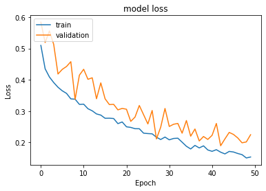

```python
#Plotting Train Loss vs Validation Loss
plt.plot(history_4.history['loss'])
plt.plot(history_4.history['val_loss'])
plt.title('model loss')
plt.ylabel('Loss')
plt.xlabel('Epoch')
plt.legend(['train', 'validation'], loc='upper left')
plt.show()
```

#### Observation

- The graph is showing less noise and a validation and test performance that is much closer indicating a reduction in overfitting.

```python
y_pred_e4=model4.predict(X_test)
y_pred_e4 = (y_pred_e4 > thresholds4[ix])
```

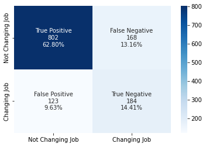

```python
#Calculating the confusion matrix
cm4=confusion_matrix(y_test, y_pred_e4)
labels = ['True Positive','False Negative','False Positive','True Negative']
categories = [ 'Not Changing Job','Changing Job']
make_confusion_matrix(cm4,
                      group_names=labels,
                      categories=categories,
                      cmap='Blues')
```

```python
#Accuracy as per the classification report
cr4=metrics.classification_report(y_test,y_pred_e4)
print(cr4)
```

```
              precision    recall  f1-score   support

           0       0.87      0.83      0.85       970
           1       0.52      0.60      0.56       307

    accuracy                           0.77      1277
   macro avg       0.69      0.71      0.70      1277
weighted avg       0.78      0.77      0.78      1277
```

### **Model 5**

Next I will add Random Search CV to identify the the best learning rate. I will Drop both Dropout and BatchNormalization since it hurt performance.

```python
backend.clear_session()
np.random.seed(1)
import random
random.seed(1)
tf.random.set_seed(1)
```

```python
def create_model_v5(lr,batch_size):
    np.random.seed(1)
    model = Sequential()
    model.add(Dense(256,activation='relu',input_dim = X_train.shape[1]))
    #model.add(Dropout(0.3))
    model.add(Dense(128,activation='relu'))
    #model.add(Dropout(0.3))
    model.add(Dense(64,activation='relu'))
    #model.add(Dropout(0.2))
    model.add(Dense(32,activation='relu'))
    model.add(Dense(1, activation='sigmoid'))

    #compile model
    optimizer = tf.keras.optimizers.Adam(learning_rate=lr)
    model.compile(optimizer = optimizer,loss = 'binary_crossentropy', metrics = ['accuracy'])
    return model
```

```python
keras_estimator = KerasClassifier(build_fn=create_model_v5, verbose=1)
# define the grid search parameters
param_random = {
    'batch_size':[32, 64, 128],
    "lr":[0.01,0.1,0.001],}

kfold_splits = 3
random= RandomizedSearchCV(estimator=keras_estimator,
                    verbose=1,
                    cv=kfold_splits,
                    param_distributions=param_random,n_jobs=-1)
```

```python
random_result = random.fit(X_sm, y_sm,validation_split=0.2,verbose=1)

# Summarize results
print("Best: %f using %s" % (random_result.best_score_, random_result.best_params_))
means = random_result.cv_results_['mean_test_score']
stds = random_result.cv_results_['std_test_score']
params = random_result.cv_results_['params']
```

```
Fitting 3 folds for each of 9 candidates, totalling 27 fits
Best: 0.646543 using {'lr': 0.001, 'batch_size': 32}
```

```python
estimator_v5=create_model_v5(batch_size=random_result.best_params_['batch_size'],lr=random_result.best_params_['lr'])

estimator_v5.summary()
```

```
Model: "sequential_1"
_________________________________________________________________
 Layer (type)                Output Shape              Param #
=================================================================
 dense_5 (Dense)             (None, 256)               2560

 dense_6 (Dense)             (None, 128)               32896

 dense_7 (Dense)             (None, 64)                8256

 dense_8 (Dense)             (None, 32)                2080

 dense_9 (Dense)             (None, 1)                 33

=================================================================
Total params: 45,825
Trainable params: 45,825
Non-trainable params: 0
_________________________________________________________________
```

```python
optimizer = tf.keras.optimizers.Adam(random_result.best_params_['lr'])
estimator_v5.compile(loss='binary_crossentropy',optimizer=optimizer,metrics=['accuracy'])
history_5=estimator_v5.fit(X_sm, y_sm, epochs=50, batch_size = 32, verbose=1,validation_split=0.2)
```

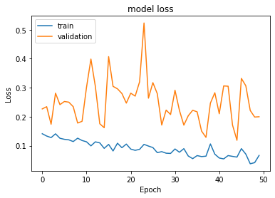

```python
#Plotting Train Loss vs Validation Loss
plt.plot(history_5.history['loss'])
plt.plot(history_5.history['val_loss'])
plt.title('model loss')
plt.ylabel('Loss')
plt.xlabel('Epoch')
plt.legend(['train', 'validation'], loc='upper left')
plt.show()
```

```
Best Threshold=0.026267, G-Mean=0.730
```

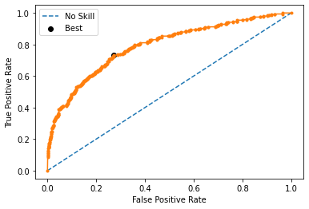

```python
from sklearn.metrics import roc_curve

from matplotlib import pyplot


# predict probabilities
yhat5 = estimator_v5.predict(X_test)
# keep probabilities for the positive outcome only
yhat5 = yhat5[:, 0]
# calculate roc curves
fpr, tpr, thresholds5 = roc_curve(y_test, yhat5)
# calculate the g-mean for each threshold
gmeans5 = np.sqrt(tpr * (1-fpr))
# locate the index of the largest g-mean
ix = np.argmax(gmeans5)
print('Best Threshold=%f, G-Mean=%.3f' % (thresholds5[ix], gmeans5[ix]))
# plot the roc curve for the model
pyplot.plot([0,1], [0,1], linestyle='--', label='No Skill')
pyplot.plot(fpr, tpr, marker='.')
pyplot.scatter(fpr[ix], tpr[ix], marker='o', color='black', label='Best')
# axis labels
pyplot.xlabel('False Positive Rate')
pyplot.ylabel('True Positive Rate')
pyplot.legend()
# show the plot
pyplot.show()
```

```python
y_pred_e5=estimator_v5.predict(X_test)
y_pred_e5 = (y_pred_e5 > thresholds5[ix])
```

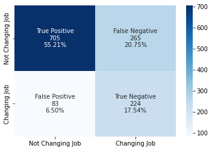

```python
#Calculating the confusion matrix
from sklearn.metrics import confusion_matrix
cm5=confusion_matrix(y_test, y_pred_e5)
labels = ['True Positive','False Negative','False Positive','True Negative']
categories = [ 'Not Changing Job','Changing Job']
make_confusion_matrix(cm5,
                      group_names=labels,
                      categories=categories,
                      cmap='Blues')
```

```python
#Accuracy as per the classification report
from sklearn import metrics
cr5=metrics.classification_report(y_test,y_pred_e5)
print(cr5)
```

```
              precision    recall  f1-score   support

           0       0.89      0.73      0.80       970
           1       0.46      0.73      0.56       307

    accuracy                           0.73      1277
   macro avg       0.68      0.73      0.68      1277
weighted avg       0.79      0.73      0.74      1277
```

### **Keras Tuner**

```python
from tensorflow import keras
from tensorflow.keras import layers
from kerastuner.tuners import RandomSearch
```

```python
backend.clear_session()
np.random.seed(1)
import random
random.seed(1)
tf.random.set_seed(1)
```

This will return optimum list of layers, number of neurons per layer, and learning rate.

```python
def build_model_6(h):
    model = keras.Sequential()
    for i in range(h.Int('num_layers', 2, 10)):
        model.add(layers.Dense(units=h.Int('units_' + str(i),
                                            min_value=32,
                                            max_value=256,
                                            step=32),
                               activation='relu'))
    model.add(layers.Dense(1, activation='sigmoid'))
    model.compile(
        optimizer=keras.optimizers.Adam(
            h.Choice('learning_rate', [1e-2, 1e-3, 1e-4])),
        loss='binary_crossentropy',
        metrics=['accuracy'])
    return model
```

```python
#Initialize Randomized Search Tuner
tuner = RandomSearch(
    build_model_6,
    objective='val_accuracy',
    max_trials=5,
    executions_per_trial=3,
     project_name='Job_')
```

```python
tuner.search_space_summary()
```

```
Search space summary
Default search space size: 4
num_layers (Int)
{'default': None, 'conditions': [], 'min_value': 2, 'max_value': 10, 'step': 1, 'sampling': None}
units_0 (Int)
{'default': None, 'conditions': [], 'min_value': 32, 'max_value': 256, 'step': 32, 'sampling': None}
units_1 (Int)
{'default': None, 'conditions': [], 'min_value': 32, 'max_value': 256, 'step': 32, 'sampling': None}
learning_rate (Choice)
{'default': 0.01, 'conditions': [], 'values': [0.01, 0.001, 0.0001], 'ordered': True}
```

```python
### Searching the best model on X and y train for the balanced dataset
tuner.search(X_sm, y_sm,
             epochs=5,
             validation_split = 0.2)
```

```
Trial 5 Complete [00h 00m 30s]
val_accuracy: 0.7764882842699686

Best val_accuracy So Far: 0.7848699688911438
Total elapsed time: 00h 02m 25s
```

```python
tuner.search_space_summary()
```

```
Search space summary
Default search space size: 11
num_layers (Int)
{'default': None, 'conditions': [], 'min_value': 2, 'max_value': 10, 'step': 1, 'sampling': None}
units_0 (Int)
{'default': None, 'conditions': [], 'min_value': 32, 'max_value': 256, 'step': 32, 'sampling': None}
units_1 (Int)
{'default': None, 'conditions': [], 'min_value': 32, 'max_value': 256, 'step': 32, 'sampling': None}
learning_rate (Choice)
{'default': 0.01, 'conditions': [], 'values': [0.01, 0.001, 0.0001], 'ordered': True}
units_2 (Int)
{'default': None, 'conditions': [], 'min_value': 32, 'max_value': 256, 'step': 32, 'sampling': None}
units_3 (Int)
{'default': None, 'conditions': [], 'min_value': 32, 'max_value': 256, 'step': 32, 'sampling': None}
units_4 (Int)
{'default': None, 'conditions': [], 'min_value': 32, 'max_value': 256, 'step': 32, 'sampling': None}
units_5 (Int)
{'default': None, 'conditions': [], 'min_value': 32, 'max_value': 256, 'step': 32, 'sampling': None}
units_6 (Int)
{'default': None, 'conditions': [], 'min_value': 32, 'max_value': 256, 'step': 32, 'sampling': None}
units_7 (Int)
{'default': None, 'conditions': [], 'min_value': 32, 'max_value': 256, 'step': 32, 'sampling': None}
units_8 (Int)
{'default': None, 'conditions': [], 'min_value': 32, 'max_value': 256, 'step': 32, 'sampling': None}
```

```python
## Printing the best models with their hyperparameters
tuner.results_summary()
```

```
Results summary
Results in ./Job_
Showing 10 best trials
<keras_tuner.engine.objective.Objective object at 0x7fb2320f0890>
Trial summary
Hyperparameters:
num_layers: 8
units_0: 160
units_1: 160
learning_rate: 0.001
units_2: 224
units_3: 96
units_4: 160
units_5: 64
units_6: 64
units_7: 192
units_8: 160
Score: 0.7848699688911438
Trial summary
Hyperparameters:
num_layers: 8
units_0: 160
units_1: 224
learning_rate: 0.001
units_2: 160
units_3: 32
units_4: 192
units_5: 96
units_6: 192
units_7: 160
units_8: 160
Score: 0.7764882842699686
Trial summary
Hyperparameters:
num_layers: 8
units_0: 64
units_1: 192
learning_rate: 0.0001
units_2: 64
units_3: 64
```

[output cut: 12 more lines]

```
units_2: 32
units_3: 32
units_4: 32
units_5: 32
units_6: 32
units_7: 32
units_8: 32
Score: 0.6931012272834778
Trial summary
Hyperparameters:
num_layers: 2
units_0: 160
units_1: 256
learning_rate: 0.0001
Score: 0.619600256284078
```

It looks like the best model will have 8 layers and learning rate of .001.